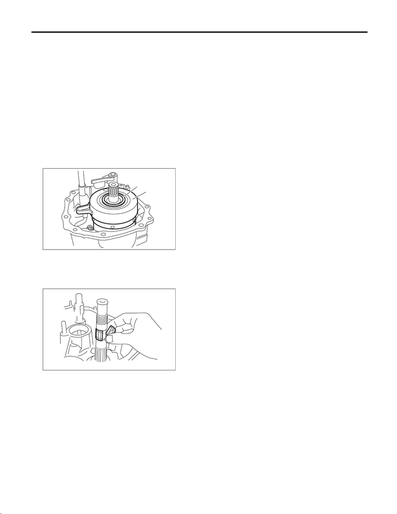

Center Differential

MANUAL TRANSMISSION AND DIFFERENTIAL

17.Center Differential

A: REMOVAL

1) Remove the manual transmission case from the

vehicle. <Ref. to 6MT(TY85)-31, REMOVAL, Man-

ual Transmission Assembly.>

2) Prepare the transmission for overhaul. <Ref. to

6MT(TY85)-38, Preparation for Overhaul.>

3) Remove the extension case. <Ref. to

6MT(TY85)-42, REMOVAL, Extension Case.>

4) Remove the transfer driven gear. <Ref. to

6MT(TY85)-54, REMOVAL, Transfer Driven

Gear.>

5) Disconnect the center differential connector.

6) Remove the adjusting washer and center differ-

ential.

7) Remove the needle bearing.

B: INSTALLATION

1) Install the needle bearing.

CAUTION:

Apply transmission gear oil onto sliding or re-

volving surfaces before installation.

2) Install the adjusting washer and center differen-

tial.

3) When replacing the center differential, select

and install the appropriate transfer drive gear and

adjusting washer. <Ref. to 6MT(TY85)-44, AD-

JUSTMENT, Extension Case.>

4) Connect the center differential connector, and

affix to the oil guide.

5) Install the transfer driven gear. <Ref. to

6MT(TY85)-54, INSTALLATION, Transfer Driven

Gear.>

6) Install the extension case. <Ref. to 6MT(TY85)-

42, INSTALLATION, Extension Case.>

7) Install the manual transmission case assembly

to the vehicle. <Ref. to 6MT(TY85)-33, INSTALLA-

TION, Manual Transmission Assembly.>

C: INSPECTION

Check that there is no damage on the center differ-

ential. Replace if damaged.

(A) Adjusting washer

(B) Center differential

(A)

(B)